# R Notebook

1. Read in the data.

```r
library(tidyverse)

diamonds <- read_csv("diamonds.csv")
head(diamonds)
```

| X1 | carat | cut | color | clarity | depth | table | price | x | y | z |
| --- | --- | --- | --- | --- | --- | --- | --- | --- | --- | --- |
| 1 | 0.23 | Ideal | E | SI2 | 61.5 | 55 | 326 | 3.95 | 3.98 | 2.43 |
| 2 | 0.21 | Premium | E | SI1 | 59.8 | 61 | 326 | 3.89 | 3.84 | 2.31 |
| 3 | 0.23 | Good | E | VS1 | 56.9 | 65 | 327 | 4.05 | 4.07 | 2.31 |
| 4 | 0.29 | Premium | I | VS2 | 62.4 | 58 | 334 | 4.20 | 4.23 | 2.63 |
| 5 | 0.31 | Good | J | SI2 | 63.3 | 58 | 335 | 4.34 | 4.35 | 2.75 |
| 6 | 0.24 | Very Good | J | VVS2 | 62.8 | 57 | 336 | 3.94 | 3.96 | 2.48 |

2. We expect the carat of the diamonds to be strong correlated with the physical dimensions x, y and z. Use ggpairs() to investigate correlations between these four variables.

```r
library(GGally)

ggpairs(diamonds)
```

[output not shown]

3. So, we do find significant correlations. Let’s drop columns x, y and z from the dataset, in preparation to use only carat going forward.

[output not shown]

[output cut: 990 more lines]

4. We are interested in developing a regression model for the price of a diamond in terms of the possible predictor variables in the dataset.
1. Use ggpairs() to investigate correlations between price and the predictors (this may take a while to run, don’t worry, make coffee or something).

There is a strong correlation of 0.922 between the price and carat.

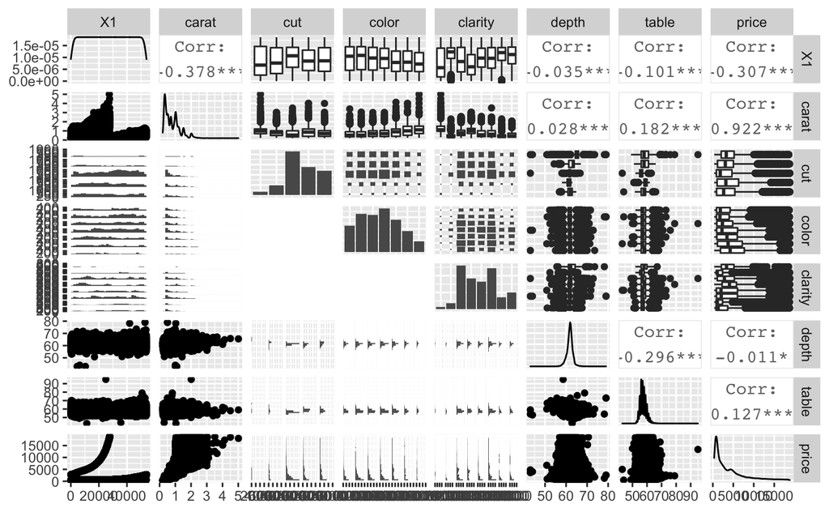

```r
ggpairs(diamonds)
```

2. Perform further ggplot visualisations of any significant correlations you find.

```r
diamonds %>%
  ggplot(aes(price, carat)) +
  geom_point()
```

[output not shown]

5. Shortly we may try a regression fit using one or more of the categorical predictors cut, clarity and color, so let’s investigate these predictors:
1. Investigate the factor levels of these predictors. How many dummy variables do you expect for each of them?

Cut = 4 Clarity = 7 Color = 6

```r
unique(diamonds$clarity)
```

```
[1] "SI2"  "SI1"  "VS1"  "VS2"  "VVS2" "VVS1" "I1"   "IF"
```

2. Use the dummy_cols() function in the fastDummies package to generate dummies for these predictors and check the number of dummies in each case.

```r
library(fastDummies)

diamonds %>%
  dummy_cols(select_columns = c("cut", "clarity", "color"), remove_first_dummy =
              TRUE, remove_selected_columns = TRUE)
```

| X1 | carat | depth | table | price | cut_Good | cut_Ideal | cut_Premium | cut_Very Good | clarity_IF | clarity_SI1 | clarity_SI2 | clarity_VS1 | clarity_VS2 | clarity_VVS1 | clarity_VVS2 | color_E | color_F | color_G | color_H | color_I | color_J |
| --- | --- | --- | --- | --- | --- | --- | --- | --- | --- | --- | --- | --- | --- | --- | --- | --- | --- | --- | --- | --- | --- |
| 1 | 0.23 | 61.5 | 55.0 | 326 | 0 | 1 | 0 | 0 | 0 | 0 | 1 | 0 | 0 | 0 | 0 | 1 | 0 | 0 | 0 | 0 | 0 |
| 2 | 0.21 | 59.8 | 61.0 | 326 | 0 | 0 | 1 | 0 | 0 | 1 | 0 | 0 | 0 | 0 | 0 | 1 | 0 | 0 | 0 | 0 | 0 |
| 3 | 0.23 | 56.9 | 65.0 | 327 | 1 | 0 | 0 | 0 | 0 | 0 | 0 | 1 | 0 | 0 | 0 | 1 | 0 | 0 | 0 | 0 | 0 |
| 4 | 0.29 | 62.4 | 58.0 | 334 | 0 | 0 | 1 | 0 | 0 | 0 | 0 | 0 | 1 | 0 | 0 | 0 | 0 | 0 | 0 | 1 | 0 |
| 5 | 0.31 | 63.3 | 58.0 | 335 | 1 | 0 | 0 | 0 | 0 | 0 | 1 | 0 | 0 | 0 | 0 | 0 | 0 | 0 | 0 | 0 | 1 |
| 6 | 0.24 | 62.8 | 57.0 | 336 | 0 | 0 | 0 | 1 | 0 | 0 | 0 | 0 | 0 | 0 | 1 | 0 | 0 | 0 | 0 | 0 | 1 |
| 7 | 0.24 | 62.3 | 57.0 | 336 | 0 | 0 | 0 | 1 | 0 | 0 | 0 | 0 | 0 | 1 | 0 | 0 | 0 | 0 | 0 | 1 | 0 |
| 8 | 0.26 | 61.9 | 55.0 | 337 | 0 | 0 | 0 | 1 | 0 | 1 | 0 | 0 | 0 | 0 | 0 | 0 | 0 | 0 | 1 | 0 | 0 |
| 9 | 0.22 | 65.1 | 61.0 | 337 | 0 | 0 | 0 | 0 | 0 | 0 | 0 | 0 | 1 | 0 | 0 | 1 | 0 | 0 | 0 | 0 | 0 |
| 10 | 0.23 | 59.4 | 61.0 | 338 | 0 | 0 | 0 | 1 | 0 | 0 | 0 | 1 | 0 | 0 | 0 | 0 | 0 | 0 | 1 | 0 | 0 |

[output cut: 990 more lines]

6. Going forward we’ll let R handle dummy variable creation for categorical predictors in regression fitting (remember lm() will generate the correct numbers of dummy levels automatically, absorbing one of the levels into the intercept as a reference level).
1. First, we’ll start with simple linear regression. Regress price on carat and check the regression diagnostics.

```
`arrange_()` is deprecated as of dplyr 0.7.0.
Please use `arrange()` instead.
See vignette('programming') for more help
```

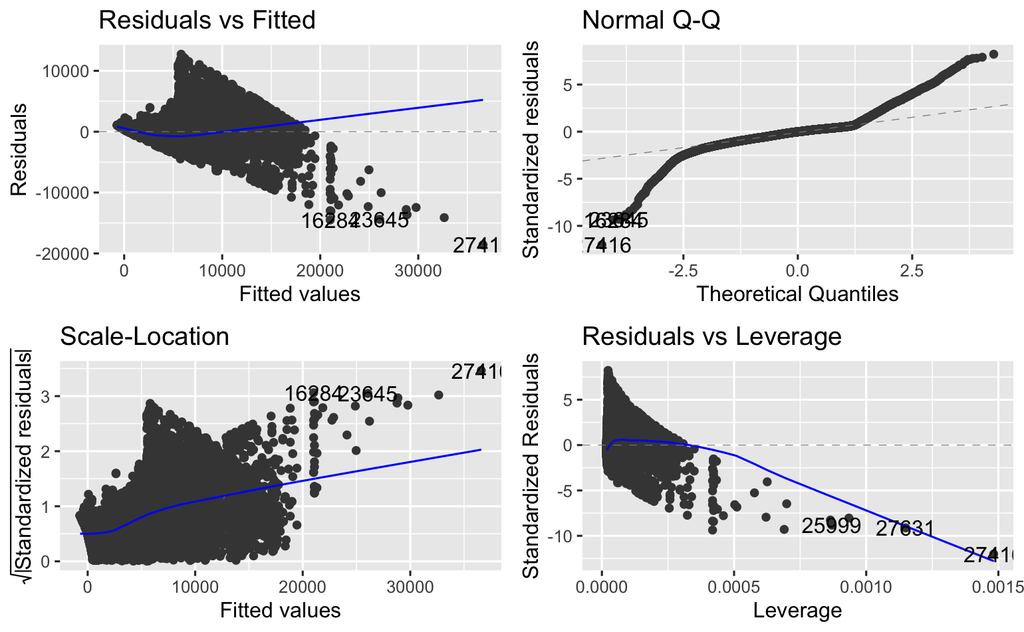

```r
library(ggfortify)
model <- lm(price ~ carat, data = diamonds)

autoplot(model)
```

2. Run a regression with one or both of the predictor and response variables log() transformed and recheck the diagnostics. Do you see any improvement?

```r
diamonds %>%
  log(carat)
```

[output not shown]

2. Let’s use log() transformations of both predictor and response. Next, experiment with adding a single categorical predictor into the model. Which categorical predictor is best? [Hint - investigate r2 values]

```r
diamonds_logs <- log(diamonds_log$price)
```

[output not shown]